# Next Empire - Data Generator and final Convolutional 2D Neural Network Model

After converting each *.mp3* file to its spectrogram, these have been chunked in 2-seconds sequences and saved to memory. Here:

- *Train* and *Test* are *.npy* files which contain the list of *.npy* files corresponding to the music chunks, respectively for the train and test set.
- *train_labels* and *test_labels* are the *.npy* files containing the list of labels for each train and test input (*Music/Speech/Advertisement*).

The GPU was not supporting the huge amount of data, therefore this method was designed to load the chunks without encountering memory-related problems.

A more detailed explanation od these steps can be found in the [Project Report.](https://drive.google.com/file/d/1sbcjbPFX8HLIGBosnztp05XA7lDKWVVw/view)

- The training set consists of 192 431 chunked spectrograms.
- The test set consists of of 48 108 spectrograms.
- The train and test labels list have, respectively, the same length.

```python
import numpy as np
import keras
import os

train=np.load("train_chunks.npy")
test=np.load("test_chunks.npy")
train_labels=np.load("train_labels.npy")
test_labels=np.load("test_labels.npy")
```

###### Checking the current GPU power to load the neural networks in TensorFlow.

```python
import tensorflow as tf
gpu_options = tf.GPUOptions(per_process_gpu_memory_fraction=0.7)
sess = tf.Session(config=tf.ConfigProto(gpu_options=gpu_options))
```

```python
from tensorflow.python.client import device_lib
device_lib.list_local_devices()
```

```
[name: "/device:CPU:0"
 device_type: "CPU"
 memory_limit: 268435456
 locality {
 }
 incarnation: 2100853751903230211, name: "/device:GPU:0"
 device_type: "GPU"
 memory_limit: 11753540813
 locality {
   bus_id: 1
   links {
   }
 }
 incarnation: 928903653624979701
 physical_device_desc: "device: 0, name: TITAN X (Pascal), pci bus id: 0000:04:00.0, compute capability: 6.1"]
```

###### Keras generator to process the huge amount of data involved in the model.

It allows to execute the Keras model on data generated batch-by-batch, while binary mapping each chunk to the corresponding label (one-hot-encoding).

```python
class DataGenerator(keras.utils.Sequence):

    def __init__(self, files, labels, batch_size=32):

        self.files=files
        self.labels=labels
        self.batch_size = batch_size


    def __len__(self):
        'Denotes the number of batches per epoch'
        return int(np.floor(len(self.files) / self.batch_size))

    def __getitem__(self, index):
        'Generate one batch of data'
        # Generate indexes of the batch

        files_batch = self.files[index*self.batch_size:(index+1)*self.batch_size]
        labels = self.labels[index*self.batch_size:(index+1)*self.batch_size]

        chunks=[]
        labels_batch = []

        for file in files_batch:
            chunk=np.load(file)
            chunks.append(chunk)

        a=np.array((1, 0, 0))
        b=np.array((0, 1, 0))
        c=np.array((0, 0, 1))

        label_map = {
            'Commercials': a,
            'Music-2sec': b,
            'Speech-2sec': c
        }

        for lab in labels:
            labels_batch.append(label_map[lab])

        chunks=np.array(chunks)
        chunks=np.reshape(chunks, (self.batch_size,1025,86,1))
        labels_batch=np.array(labels_batch)

        return chunks, labels_batch
```

```python
# Parameters
params = {'batch_size': 64}

training_generator = DataGenerator(train, train_labels, **params)
validation_generator = DataGenerator(test, test_labels, **params)
```

#### Final Keras 2D CNN model.

```python
import numpy as np
from keras import optimizers, losses, activations, models
from keras.callbacks import ModelCheckpoint, EarlyStopping
from keras.layers import Dense, Input, Dropout, BatchNormalization, Convolution2D, MaxPooling2D, GlobalMaxPool2D, Flatten


def get_model_mel():
    nclass = 3
    inp = Input(shape=(1025,86,1))
    norm_inp = BatchNormalization()(inp)
    img_1 = Convolution2D(16, kernel_size=(3, 7), activation=activations.relu)(norm_inp)
    img_1 = Convolution2D(16, kernel_size=(3, 7), activation=activations.relu)(img_1)
    img_1 = MaxPooling2D(pool_size=(3, 7))(img_1)
    img_1 = Dropout(rate=0.1)(img_1)
    img_1 = Convolution2D(32, kernel_size=3, activation=activations.relu)(img_1)
    img_1 = Convolution2D(32, kernel_size=3, activation=activations.relu)(img_1)
    img_1 = MaxPooling2D(pool_size=(3, 3))(img_1)
    dense_1 = BatchNormalization()(Dense(128, activation=activations.relu)(img_1))
    dense_1 = BatchNormalization()(Dense(128, activation=activations.relu)(dense_1))
    dense_1 = Flatten()(dense_1)
    dense_1 = Dense(nclass, activation=activations.softmax)(dense_1)
    model = models.Model(inputs=inp, outputs=dense_1)
    opt = optimizers.Adam()
    model.compile(optimizer=opt, loss="categorical_crossentropy", metrics=['acc'])
    model.summary()
    return model


model = get_model_mel()

# Train model on dataset
history=model.fit_generator(epochs=20,
                    generator=training_generator,
                    validation_data=validation_generator, use_multiprocessing=True)

model.save('CNN_2D.h5')

print(history.history.keys())
```

```
_________________________________________________________________
Layer (type)                 Output Shape              Param #
=================================================================
input_2 (InputLayer)         (None, 1025, 86, 1)       0
_________________________________________________________________
batch_normalization_4 (Batch (None, 1025, 86, 1)       4
_________________________________________________________________
conv2d_5 (Conv2D)            (None, 1023, 80, 16)      352
_________________________________________________________________
conv2d_6 (Conv2D)            (None, 1021, 74, 16)      5392
_________________________________________________________________
max_pooling2d_3 (MaxPooling2 (None, 340, 10, 16)       0
_________________________________________________________________
dropout_2 (Dropout)          (None, 340, 10, 16)       0
_________________________________________________________________
conv2d_7 (Conv2D)            (None, 338, 8, 32)        4640
_________________________________________________________________
conv2d_8 (Conv2D)            (None, 336, 6, 32)        9248
_________________________________________________________________
max_pooling2d_4 (MaxPooling2 (None, 112, 2, 32)        0
_________________________________________________________________
dense_4 (Dense)              (None, 112, 2, 128)       4224
_________________________________________________________________
batch_normalization_5 (Batch (None, 112, 2, 128)       512
_________________________________________________________________
dense_5 (Dense)              (None, 112, 2, 128)       16512
_________________________________________________________________
batch_normalization_6 (Batch (None, 112, 2, 128)       512
_________________________________________________________________
flatten_2 (Flatten)          (None, 28672)             0
_________________________________________________________________
dense_6 (Dense)              (None, 3)                 86019
=================================================================
Total params: 127,415
Trainable params: 126,901
Non-trainable params: 514
_________________________________________________________________
```

[output not shown]

[output not shown]

[output not shown]

[output not shown]

[output not shown]

[output not shown]

```python
!nvidia-smi
```

```
Wed Oct 24 11:59:30 2018
+-----------------------------------------------------------------------------+
| NVIDIA-SMI 390.30                 Driver Version: 390.30                    |
|-------------------------------+----------------------+----------------------+
| GPU  Name        Persistence-M| Bus-Id        Disp.A | Volatile Uncorr. ECC |
| Fan  Temp  Perf  Pwr:Usage/Cap|         Memory-Usage | GPU-Util  Compute M. |
|===============================+======================+======================|
|   0  TITAN X (Pascal)    Off  | 00000000:04:00.0  On |                  N/A |
| 41%   71C    P2    64W / 250W |  12192MiB / 12194MiB |      0%      Default |
+-------------------------------+----------------------+----------------------+

+-----------------------------------------------------------------------------+
| Processes:                                                       GPU Memory |
|  GPU       PID   Type   Process name                             Usage      |
|=============================================================================|
+-----------------------------------------------------------------------------+
```

```python
history=model.fit_generator(epochs=20,
                    generator=training_generator,
                    validation_data=validation_generator)
```

[output not shown]

[output not shown]

[output not shown]

[output not shown]

[output not shown]

[output not shown]

[output not shown]

[output not shown]

[output not shown]

[output not shown]

```python
# list all data in history
print(history.history.keys())
```

```
dict_keys(['val_loss', 'val_acc', 'loss', 'acc'])
```

```python
from keras.models import load_model
CNN_2D = load_model('CNN_2D.h5') # load the saved model

CNN_2D.summary()
CNN_2D.get_weights()
```

```
_________________________________________________________________
Layer (type)                 Output Shape              Param #
=================================================================
input_2 (InputLayer)         (None, 1025, 86, 1)       0
_________________________________________________________________
batch_normalization_4 (Batch (None, 1025, 86, 1)       4
_________________________________________________________________
conv2d_5 (Conv2D)            (None, 1023, 80, 16)      352
_________________________________________________________________
conv2d_6 (Conv2D)            (None, 1021, 74, 16)      5392
_________________________________________________________________
max_pooling2d_3 (MaxPooling2 (None, 340, 10, 16)       0
_________________________________________________________________
dropout_2 (Dropout)          (None, 340, 10, 16)       0
_________________________________________________________________
conv2d_7 (Conv2D)            (None, 338, 8, 32)        4640
_________________________________________________________________
conv2d_8 (Conv2D)            (None, 336, 6, 32)        9248
_________________________________________________________________
max_pooling2d_4 (MaxPooling2 (None, 112, 2, 32)        0
_________________________________________________________________
dense_4 (Dense)              (None, 112, 2, 128)       4224
_________________________________________________________________
batch_normalization_5 (Batch (None, 112, 2, 128)       512
_________________________________________________________________
dense_5 (Dense)              (None, 112, 2, 128)       16512
_________________________________________________________________
batch_normalization_6 (Batch (None, 112, 2, 128)       512
_________________________________________________________________
flatten_2 (Flatten)          (None, 28672)             0
_________________________________________________________________
dense_6 (Dense)              (None, 3)                 86019
=================================================================
Total params: 127,415
Trainable params: 126,901
Non-trainable params: 514
_________________________________________________________________
```

#### Model evaluation: Training and Validation loss and accuracy.

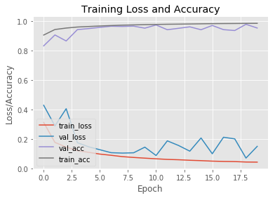

```python
import matplotlib.pyplot as plt
import numpy as np

# plot the training loss and accuracy
plt.style.use("ggplot")
plt.figure()
N = 20 #epoches
plt.plot(np.arange(0, N), history.history["loss"], label="train_loss")
plt.plot(np.arange(0, N), history.history["val_loss"], label="val_loss")
plt.plot(np.arange(0, N), history.history["val_acc"], label="val_acc")
plt.plot(np.arange(0, N), history.history["acc"], label="train_acc")
plt.plot()
plt.title("Training Loss and Accuracy")
plt.xlabel("Epoch")
plt.ylabel("Loss/Accuracy")
plt.legend(loc="lower left")
```

The accuracy trend on the train set was still rising for the last few epochs, and the validation accuracy never over-learned the training one.

The train loss smoothly decreased over time, showing that the model is learning over the epochs.